# Principal Component Analysis (PCA) - Linear

[scikit-learn Doc](http://scikit-learn.org/stable/modules/decomposition.html#pca)

[scikit-learn Parameters](http://scikit-learn.org/stable/modules/generated/sklearn.decomposition.PCA.html#sklearn.decomposition.PCA)

- Linear dimensionality reduction using Singular Value Decomposition of the data to project it to a lower dimensional space.

1901 by Karl Pearson

- Unsupervised Machine Learning

[Wikipedia](https://en.wikipedia.org/wiki/Principal_component_analysis)

- Statistical procedure that utilise [orthogonal transformation](https://en.wikipedia.org/wiki/Orthogonal_transformation) technology
- Convert possible correlated features (predictors) into linearly uncorrelated features (predictors) called **principal components**
- # of principal components <= number of features (predictors)
- First principal component explains the largest possible variance
- Each subsequent component has the highest variance subject to the restriction that it must be orthogonal to the preceding components.
- A collection of the components are called vectors.
- Sensitive to scaling

**Note:**

- Used in exploratory data analysis (EDA)
- Visualize genetic distance and relatedness between populations.
- Method:
  - Eigenvalue decomposition of a data covariance (or correlation) matrix
  - Singular value decomposition of a data matrix (After mean centering / normalizing ) the data matrix for each attribute.
- Output
  - Component scores, sometimes called **factor scores** (the transformed variable values)
  - **loadings** (the weight)
- Data compression and information preservation
- Visualization
- Noise filtering
- Feature extraction and engineering

```python
import numpy as np
import matplotlib.pyplot as plt
%matplotlib inline
import pandas as pd
import seaborn as sns
sns.set()
```

```python
rnd_num = np.random.RandomState(42)
X = np.dot(rnd_num.rand(2,2), rnd_num.randn(2, 500)).T
```

```python
X
```

[output not shown]

[output cut: 445 more lines]

[output not shown]

```python
X[:, 0] = - X[:, 0]
```

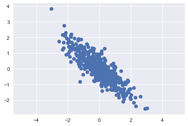

```python
plt.scatter(X[:, 0], X[:, 1]);
plt.axis('equal');
```

## Principal Components Identification

```python
from sklearn.decomposition import PCA
```

```python
pca = PCA(n_components=2)
pca.fit(X)
```

```
PCA(copy=True, iterated_power='auto', n_components=2, random_state=None,
  svd_solver='auto', tol=0.0, whiten=False)
```

```python
print(pca.components_)
```

```
[[-0.74062812  0.67191517]
 [-0.67191517 -0.74062812]]
```

```python
print(pca.explained_variance_)
```

```
[1.62123504 0.12581594]
```

```python
print(pca.explained_variance_ratio_)
```

```
[0.92798382 0.07201618]
```

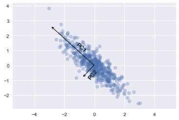

```python
plt.scatter(X[:, 0], X[:, 1], alpha=0.3)


# plot data

for k, v in zip(pca.explained_variance_, pca.components_):
    vec = v * 3 * np.sqrt(k)

    ax = plt.gca()
    arrowprops=dict(arrowstyle='<-',
                    linewidth=1,
                    shrinkA=0, shrinkB=0)
    ax.annotate('', pca.mean_, pca.mean_ + vec, arrowprops=arrowprops)
    ax.text(-0.90, 1.2,'PC1', ha='center', va='center', rotation=-42, size=12)
    ax.text(-0.1,-0.6,'PC2', ha='center', va='center', rotation=50, size=12)
plt.axis('equal');
```

- Two principal components
- Length denotes the significance

This transformation from data axes to principal axes is as an affine transformation, which basically means it is composed of a translation, rotation, and uniform scaling.

## Dimensionality Reduction with PCA

```python
pca = PCA(n_components=1)
pca.fit(X)
X_pca = pca.transform(X)
```

```python
X.shape
```

```
(500, 2)
```

```python
X_pca.shape
```

```
(500, 1)
```

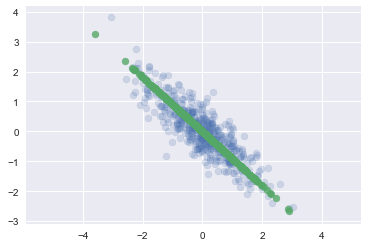

```python
X_new = pca.inverse_transform(X_pca)
plt.scatter(X[:, 0], X[:, 1], alpha=0.2);
plt.scatter(X_new[:, 0], X_new[:, 1], alpha=0.8)
plt.axis('equal');
```

The Green is the PCA

The light blue is the original data